# PSTAT127 | Fall 2024 | Homework 1

Billy Dang

2024-10-07

```r
library(dplyr)
library(tinytex)
library(tidyverse)
library(ggplot2)
library(ggthemes)
```

## Question 1

### Part 1

Plot the data with alcohol on the vertical axis, and tobacco on the horizontal axis (scatterplot). Present your code here:

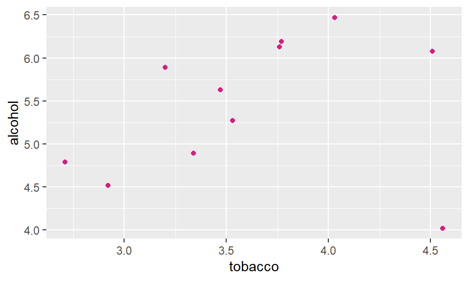

```r
#Create data frame to prep for plotting

spending_data <- data.frame(
  region = c("North", "Yorkshire", "Northeast", "East Midlands", "West Midlands", "East Anglia", "Southeast", "Southwest", "Wales", "Scotland", "Northern Ireland"),
  alcohol = c(6.47, 6.13, 6.19, 4.89, 5.63, 4.52, 5.89, 4.79, 5.27, 6.08, 4.02),
  tobacco = c(4.03, 3.76, 3.77, 3.34, 3.47, 2.92, 3.20, 2.71, 3.53, 4.51, 4.56)
)

#Create scatterplot
ggplot(spending_data,
       aes(x = tobacco, y = alcohol)) + geom_point(color = "#D51E80")
```

### Part B Fit a simple Gaussian homoskedastic linear regression of alcohol spending on tobacco spending (include both an intercept & slope) and add the fitted line to the scatter plot produced above.

```r
#Fitting the model and examining results
linear_model <- lm(tobacco ~ alcohol, data = spending_data)
```

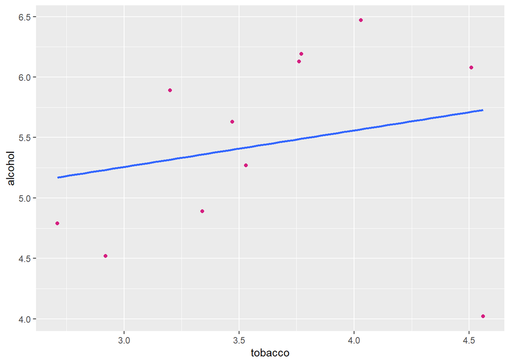

```r
ggplot(spending_data,
       aes(x = tobacco, y = alcohol)) +
  geom_point(color = "#D51E80") +
  geom_smooth(method = 'lm', se = FALSE)
```

### Part C

Write down corresponding model and assumptions, clearly defining notation. You may write this model in the way you did in PSTA 126 - using additive error with assumptions on the random variables. (**The underlying model & assumptions not the resulting numeric equation for the fitted values**)

$H_0: \beta_1 = 0$ - Alcohol spending does not have a significant effect on tobacco spending.

$H_1: \beta_1 \neq 0$ - Alcohol spending does have a significant effect on tobacco spending.

$ Y_i$ is the ddependent (response) variable, in this case, the “Tobacco” spending for observations i.

$ X_i$ is the independent (predictor) variable, which is the “Alcohol” spending for observations i.

### Part D

```r
summary(linear_model)
```

```
##
## Call:
## lm(formula = tobacco ~ alcohol, data = spending_data)
##
## Residuals:
##      Min       1Q   Median       3Q      Max
## -0.79998 -0.33930 -0.05944  0.13508  1.17749
##
## Coefficients:
##             Estimate Std. Error t value Pr(>|t|)
## (Intercept)   2.7170     1.3223   2.055   0.0701 .
## alcohol       0.1655     0.2406   0.688   0.5087
## ---
## Signif. codes:  0 '***' 0.001 '**' 0.01 '*' 0.05 '.' 0.1 ' ' 1
##
## Residual standard error: 0.6069 on 9 degrees of freedom
## Multiple R-squared:  0.04998,    Adjusted R-squared:  -0.05557
## F-statistic: 0.4735 on 1 and 9 DF,  p-value: 0.5087
```

### Part E

Obtain the leverage values using any approach you studied in PSTAT 126 (Make sure you review the formulae for the future, and review how leverage values are used in linear model diagnostics)

```r
#Where values greater than (2p/n) are considered leverage values
leverage <- hatvalues(linear_model)
print(leverage)
```

```
##          1          2          3          4          5          6          7
## 0.25643080 0.16493112 0.17843838 0.13907078 0.09636635 0.22495529 0.12221527
##          8          9         10         11
## 0.15804036 0.09564642 0.15453927 0.40936595
```

### Part F

Calculate the Cook’s distance measures, and identify which region has the highest Cook’s distance value.

```r
cooks_list = cooks.distance(linear_model)
print(cooks_list)
```

```
##            1            2            3            4            5            6
## 0.0368438585 0.0002552132 0.0002866311 0.0088620348 0.0051350490 0.1511521822
##            7            8            9           10           11
## 0.0521372411 0.1936753179 0.0005608457 0.1815319866 2.2086563751
```

### Part G

What do the Cook’s distances indicate in this dat set, i.e. do any points seem potentially influential requiring further investigation?

### Part H

Can you think of a brief geographic reason that might explain what you are seeing, and any further research that you would do about geographic variation in smoking and drinking practices?

### Part I

Comment on the sensitivity of your regression coefficients to the point with highest Cook’s distance measure. (Fir the model both with and without that point, and comment on how your coefficients, fitted values, and hypothesis test decisions change.)

### Part J

Plot the observations with your fitted line superimposed for each of these fits from the previous part. The plot for each of these fits may be a separate panel or on the same panel. If using two panels, specify R options to control the axis ranges of the adjacent panels to be the same so you can compare the lines.